# A (very) brief survey of climate statistics

### Context

These slides are a miscellanious collection of notes that I (a statistics grad student) wish I had starting out in climate science.

- I think most of this is well understood by climate scientists, but I’ve never seen it written out in a language that makes sense to me.
- caveats: a lot of this is oversimplified for the sake of clarity

### motivation I<sup>1</sup>

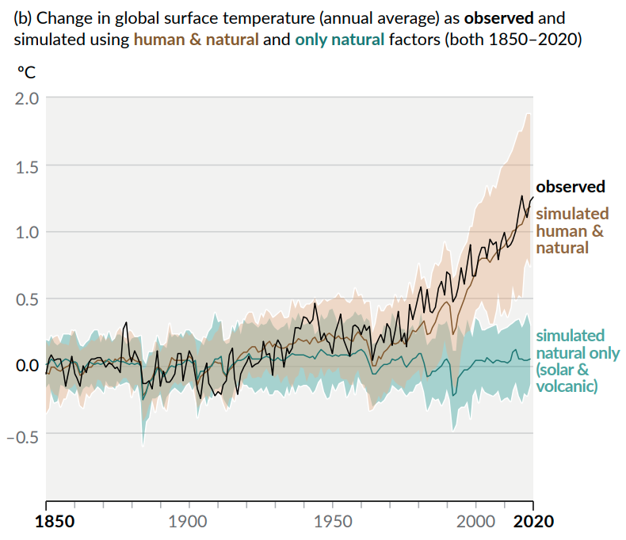

where does the uncertainty come from, and what does it tell us?

[^1]: IPCC AR6 WG1, SPM Figure 1b

### motivation II<sup>1</sup>

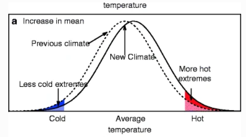

Goal: Want the distribution of average daily temperature in LA on April 28, 2023.

- Approach 1: from observations, compute average temperature every day in the season $\to$ histogram
- Approach 2: from a bunch of different climate model runs, compute average temperature on April 28, 2023 $\to$ histogram

**what’s the difference?**

[^2]: Fig 1, Zwiers et al 2013. schematic of daily temperature

### Schematic I: data

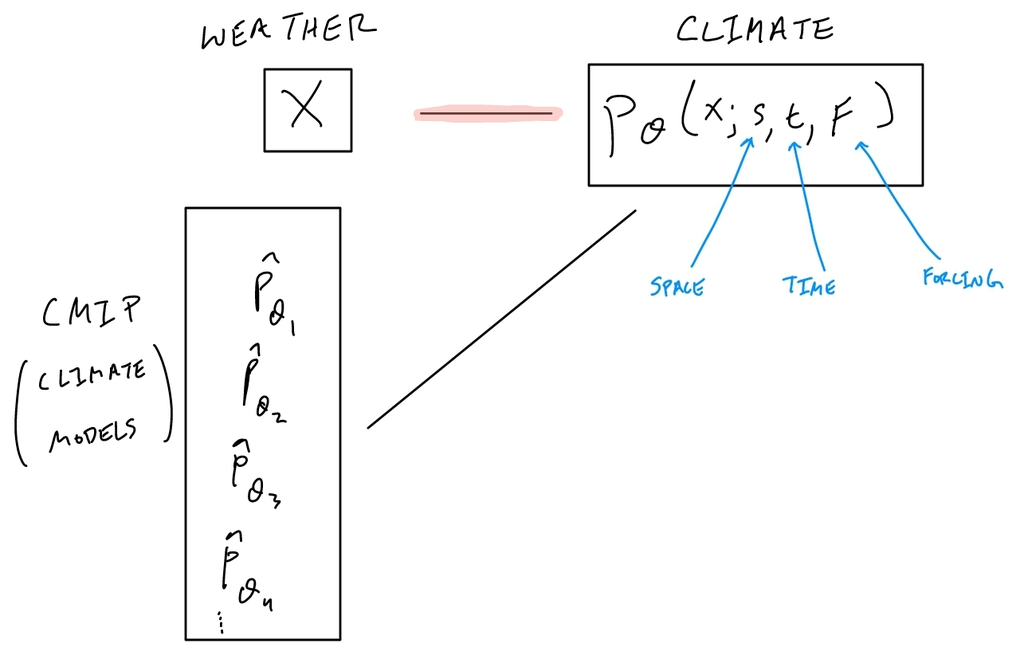

- We observe weather data
- We consider the data to be a *single draw* from some distribution of possible weather, $p_\theta(x ; s, t, F)$ (where $\theta$ is shorthand for model physics/parametrizations)
  - we call $p_\theta$ climate (but sometimes we refer to climate as just the mean).
- our goal is to understand $p_\theta$
  - $p_\theta$ is super complicated, but there are many constraints!

### Schematic II: climate models

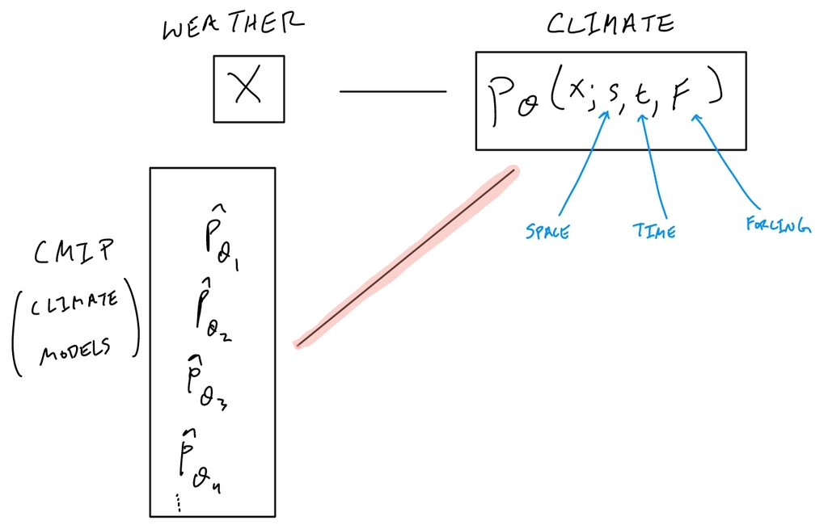

Each climate modelling center creates a climate model $\hat p_\theta$, which approximates $p_\theta$ by modelling the underlying physics.

The three sources of uncertainty:

- structural uncertainty in $\hat \theta$ (including discretization error),
- forcing uncertainty in $F$,
- internal variability $Var_\theta(X)$.

### what’s the point of all the notation?

- mostly an organization tool for me, but maybe useful to:
  - help categorize different directions of climate research
  - help make stats assumptions explicit (and figure out how to weaken them)
  - help connect new stats methods to climate

**Fundamental question**: Given observations $x_{obs}$ and models $\hat p_\theta$, what can we say about climate $p_\theta$?

**Idea:** We can organize climate stats research according to the types of assumptions they make about the relationships between $x_{obs}, \ \hat p_\theta$, and $p_\theta$.

### Multi-model ensemble means<sup>1</sup>

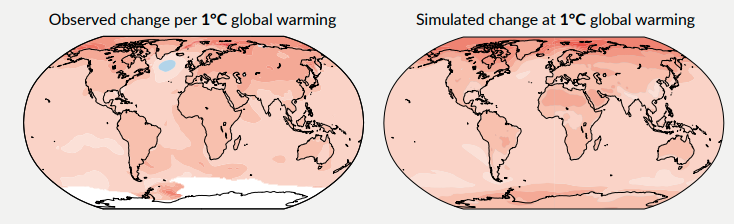

Idea: The multi-model ensemble mean $\frac{1}{M}\sum_{m=1}^M x_m$ represents our best understanding of the true $E_\theta[X]$

- $m$ indexes over different climate models
- Assumes unbiased-ness: $\hat p_{\theta_m}$’s are centered around the true $p_\theta$
- varying levels of conditioning on $x_{obs}$
[^3]: IPCC AR6 WG 1 SPM Figure 5.

### Multi-model ensemble spread<sup>1</sup>

multi-model ensemble spread represents:

- distances of $\hat p_{\theta_m}$’s from one another.
  - physics uncertainty
  - discretization error
- internal variability (sometimes)

Ensemble spread does not represent:

- distances from $\hat p_{\theta_m}$’s to $p_\theta$

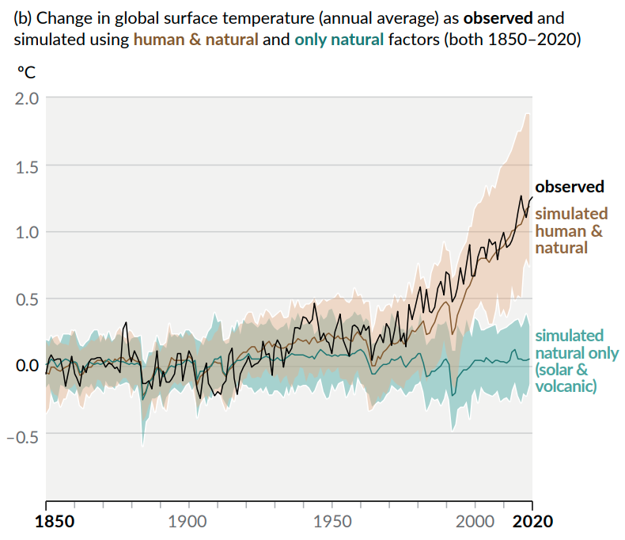

[^4]: IPCC AR6 WG1, SPM Figure 1b

### Single-model ensembles<sup>1</sup>

*if we average many runs from the same climate model, we can separate climate signal from internal variability*

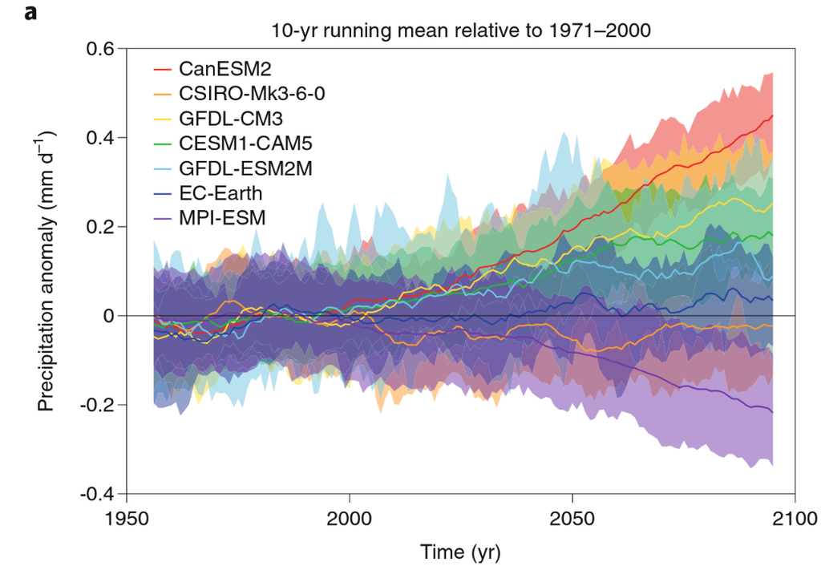

- Running the same model with different initial conditions gives multiple draws from $\hat p_\theta$.
- The mean climate of a single-model ensemble gives the climate signal, given physics $\hat \theta$
[^5]: Fig2a, Deser et al 2020. 10 year running mean, over upper colorado river basin

### “Systematic Bias” of climate models<sup>1</sup>

*oversimplified idea: if our climate models look different from observations, then there’s something wrong with our climate model* (aka understand error in $\hat \theta$)

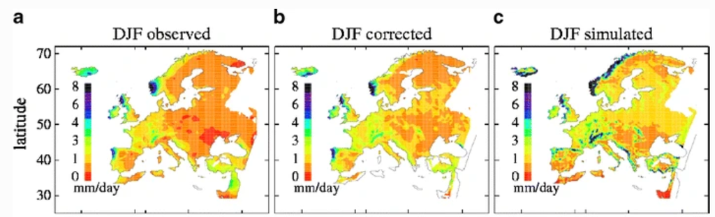

- Why do climate model runs look different from observations?
  - propagation of error in $\hat \theta$
  - internal variability

Example: Quantile mapping assumes stationarity to show “systematic” bias

[^6]: Piani et al 2009 Fig 2. mean daily precipitation in observations (a), climate model output before (c) and after (b) correction

### detection and attribution<sup>1</sup>

*oversimplified idea: We can add forcings into our climate model one by one to see how each forcing contributes to observed trends* (aka understand $p_\theta(x|F)$)

- assume $y = \sum_{i=1}^p \beta_i x_i + \epsilon$
  - $x_i$ are “fingerprints”,
  - $y$ are observed changes
- climate model evaluation is trickier with separated forcings
  - assumes climate signal is additive
  - roughly: $p_\theta(y^{obs}_t - y_{t-k}^{obs} | F) = \hat p_\theta (y_t^m - y_{t-k}^{m} | F)$

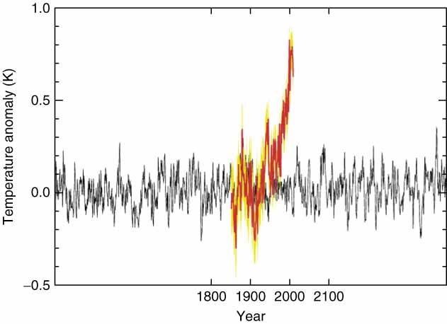

[^7]: Fig 1, Stott et al 2010. global mean temperature change. Black line shows control simulation

### Emergent constraints<sup>1</sup>

*oversimplified idea: if two things are related in all climate models, then they should also be related in observations* (aka understand $p_\theta$($Y|X$))

- $y_i = x_i^T \beta + \epsilon_i$ where $i$ indexes over ensemble members
- clear signal in $\beta$ suggests $y_{obs} = x_{obs}^T \beta + \epsilon$
- Assumes $\hat p_\theta(y|x) = p_\theta(y|x)$
- requires a good model for $\hat p_\theta(y|x)$ from ensemble

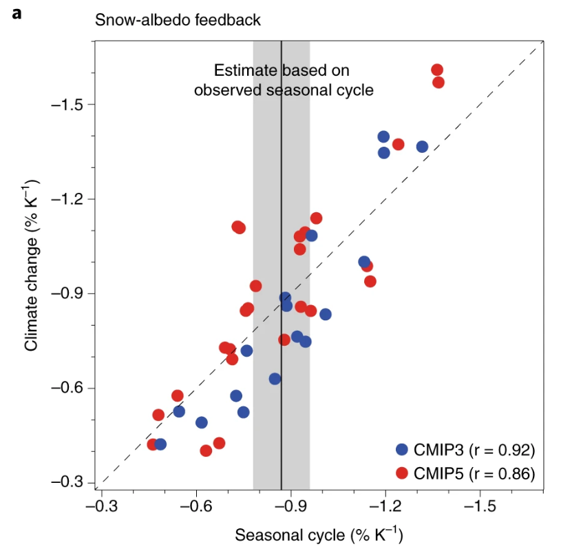

[^8]: Fig 2a from Hall et al 2019. EC on snow-albedo feedbacks. percent albedo change per unit warming, under climate change (y-axis) and current seasonal cycle (x-axis) in climate models

### Climate models and traditional geostatistics

Traditional methods try to learn things about $p_\theta$ using observations alone:

- EOFs to understand spatio-temporal patterns of variability
- regressions to determine observational trends
- extreme value models
- stats for extending the observational record spatially (e.g. GPs) and temporally (e.g. paleoclimate)
- stats for improving the quality of the observational record (e.g. combining data sources)

**Idea:** climate models can be used as a methodological testbed for these methods

- a single climate model run is analagous to observations,
- and can be validated against other climate models

### Example: The observational large ensemble<sup>1</sup>

1. Spread across initial condition ensemble provides $\widehat Var_{\hat \theta}(X)$ (here, $X$ is a temperature trend)
2. Make structural assumption about $p_\theta$ to obtain “multiple samples” of $x_{obs}$ (block bootstrap)
3. Spread across these new “samples” provides $\widehat Var_{\theta}(X)$

ObsLE: Add noise (with variance $\widehat Var_\theta(X)$) to $E_{\hat \theta}[X]$

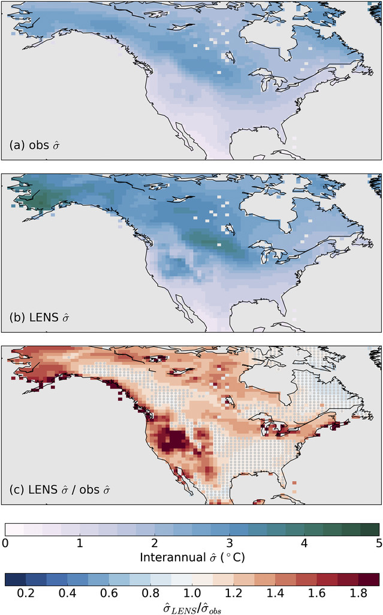

[^9]: Fig 1, McKinnon et al 2017. internal variability of detrended DJF temperature

### References

Deser, C., F. Lehner, K. B. Rodgers, et al. 2020. “Insights from Earth System Model Initial-Condition Large Ensembles and Future Prospects.” *Nature Climate Change* 10 (4): 277–86. https://doi.org/10.1038/s41558-020-0731-2.

Hall, Alex, Peter Cox, Chris Huntingford, and Stephen Klein. 2019. “Progressing Emergent Constraints on Future Climate Change.” *Nature Climate Change* 9 (4): 269–78. https://doi.org/10.1038/s41558-019-0436-6.

McKinnon, Karen A., Andrew Poppick, Etienne Dunn-Sigouin, and Clara Deser. 2017. “An ‘Observational Large Ensemble’ to Compare Observed and Modeled Temperature Trend Uncertainty Due to Internal Variability.” *Journal of Climate* 30 (19): 7585–98. https://doi.org/10.1175/JCLI-D-16-0905.1.

Piani, C., J. O. Haerter, and E. Coppola. 2010. “Statistical Bias Correction for Daily Precipitation in Regional Climate Models over Europe.” *Theoretical and Applied Climatology* 99 (1): 187–92. https://doi.org/10.1007/s00704-009-0134-9.

Stott, Peter A., Nathan P. Gillett, Gabriele C. Hegerl, et al. 2010. “Detection and Attribution of Climate Change: A Regional Perspective.” *WIREs Climate Change* 1 (2): 192–211. https://doi.org/10.1002/wcc.34.

Zwiers, Francis W., Lisa V. Alexander, Gabriele C. Hegerl, et al. 2013. “Climate Extremes: Challenges in Estimating and Understanding Recent Changes in the Frequency and Intensity of Extreme Climate and Weather Events.” In *Climate Science for Serving Society: Research, Modeling and Prediction Priorities*, edited by Ghassem R. Asrar and James W. Hurrell. Springer Netherlands. https://doi.org/10.1007/978-94-007-6692-1_13.